# Linear Model Analysis of Rosner `lead` Dataset

FE Harrell

2017-04-17

# Data Description

```r
# results='asis' in the chunk header because html(contents) output html directly
require(rms)
```

```r
knitrSet(lang='markdown')
options(prType='html')   # html output for print, summary, anova
getHdata(lead)
html(contents(lead), maxlevels=10, levelType='table')
```

#### Data frame:lead

124 observations and 39 variables, maximum # NAs:40

| Name | Labels | Units | Levels | Storage | NAs |
| --- | --- | --- | --- | --- | --- |
| id |  |  |  | integer | 0 |
| area |  |  | 3 | integer | 0 |
| age | Age in years |  |  | double | 0 |
| sex |  |  | 2 | integer | 0 |
| inf | Information Subtest |  |  | integer | 0 |
| comp | Comprehension Subtest |  |  | integer | 0 |
| ar | Arithmetic Subtest |  |  | integer | 0 |
| ds | Digit Span Subtest and Sentence Completion |  |  | integer | 0 |
| v.raw | Raw Score/Verbal IQ |  |  | integer | 0 |
| pc | Picture Completion Subtest |  |  | integer | 0 |
| bd | Block Design Subtest |  |  | integer | 0 |
| oa | Object Assembly Subtest, Animal House Subtest |  |  | integer | 0 |
| cod | Coding Subtest, Geometric Design Subtest |  |  | integer | 0 |
| p.raw | Raw Score/Performance IQ |  |  | integer | 0 |
| hh.index | Hollingshead Index of Social Status |  |  | integer | 0 |
| iqv | Verbal IQ |  |  | integer | 0 |
| iqp | Performance IQ |  |  | integer | 0 |
| iqf | Full Scale IQ |  |  | integer | 0 |
| test.type |  |  | 2 | integer | 0 |
| ld72 | Blood Lead Levels, 1972 | mg/100ml |  | integer | 0 |
| ld73 | Blood Lead Levels, 1973 | mg/100ml |  | integer | 0 |
| frst2yrs |  |  | 2 | integer | 0 |
| totyrs | Total No. Years Spent within 4.1m |  |  | integer | 0 |
| pica |  |  | 2 | integer | 0 |
| colic |  |  | 2 | integer | 0 |
| clumsy |  |  | 2 | integer | 0 |
| irritable |  |  | 2 | integer | 0 |
| convulsions |  |  | 2 | integer | 0 |
| rt.taps.10s | # Taps Right Hand |  |  | integer | 25 |
| lt.taps.10s | # Taps Left Hand |  |  | integer | 25 |
| rt.visual | Visual Reaction Time Right Hand | ms |  | integer | 25 |
| lt.visual | Visual Reaction Time Left Hand | ms |  | integer | 25 |
| rt.auditory | Auditory Reaction Time Right Hand | ms |  | integer | 25 |
| lt.auditory | Auditory Reaction Time Left Hand | ms |  | integer | 25 |
| rt.f.w.tap | Finger-Wrist Tapping Test Right Hand | taps/10s |  | integer | 25 |
| lt.f.w.tap | Finger-Wrist Tapping Test Left Hand | taps/10s |  | integer | 25 |
| wwps | Werry-Weiss-Peters Hyperactivity Scale |  |  | integer | 40 |
| group |  |  | 3 | integer | 0 |
| maxfwt | Maximum mean finger-wrist tapping score |  |  | integer | 25 |

| Variable | Levels |
| --- | --- |
| area | 0-1m |
|  | 1-2.5m |
|  | 2.5-4.1m |
| sex | male |
|  | female |
| test.type | WISC |
|  | WPPSI |
| frst2yrs, pica, colic, clumsy | yes |
| irritable, convulsions | no |
| group | blood lead < 40mg/100ml in 1972&1973 |
|  | blood lead >= 40mg/100ml in 1973 |
|  | blood lead >= 40 in 1972, < 40 in 1973 |

```r
html(describe(lead))
```

lead  
39 Variables 124 Observations

id

| n | missing | distinct | Info | Mean | Gmd | .05 | .10 | .25 | .50 | .75 | .90 | .95 |
| --- | --- | --- | --- | --- | --- | --- | --- | --- | --- | --- | --- | --- |
| 124 | 0 | 124 | 1 | 240.2 | 151.3 | 107.2 | 113.3 | 131.8 | 162.5 | 311.2 | 414.7 | 586.6 |

lowest : 101 102 103 104 105 , highest: 603 604 605 606 607

area

| n | missing | distinct |
| --- | --- | --- |
| 124 | 0 | 3 |

```
 Value          0-1m   1-2.5m 2.5-4.1m
 Frequency        57       45       22
 Proportion    0.460    0.363    0.177
```

age: Age in years

| n | missing | distinct | Info | Mean | Gmd | .05 | .10 | .25 | .50 | .75 | .90 | .95 |
| --- | --- | --- | --- | --- | --- | --- | --- | --- | --- | --- | --- | --- |
| 124 | 0 | 73 | 1 | 8.935 | 4.074 | 3.929 | 4.333 | 6.167 | 8.375 | 12.021 | 14.000 | 15.000 |

| lowest : | 3.750000 | 3.833333 | 3.916667 | 4.000000 | 4.166667 |
| --- | --- | --- | --- | --- | --- |
| highest: | 14.250000 | 15.000000 | 15.250000 | 15.416667 | 15.916667 |

sex

| n | missing | distinct |
| --- | --- | --- |
| 124 | 0 | 2 |

```
 Value        male female
 Frequency      76     48
 Proportion  0.613  0.387
```

inf: Information Subtest

| n | missing | distinct | Info | Mean | Gmd | .05 | .10 | .25 | .50 | .75 | .90 | .95 |
| --- | --- | --- | --- | --- | --- | --- | --- | --- | --- | --- | --- | --- |
| 124 | 0 | 13 | 0.977 | 6.766 | 2.603 | 4.00 | 4.00 | 5.00 | 6.00 | 8.00 | 10.00 | 11.85 |

```
 Value          2     3     4     5     6     7     8     9    10    11    12    13
 Frequency      3     2    13    20    25    24    14     9     3     4     3     3
 Proportion 0.024 0.016 0.105 0.161 0.202 0.194 0.113 0.073 0.024 0.032 0.024 0.024

 Value         15
 Frequency      1
 Proportion 0.008
```

comp: Comprehension Subtest

| n | missing | distinct | Info | Mean | Gmd | .05 | .10 | .25 | .50 | .75 | .90 | .95 |
| --- | --- | --- | --- | --- | --- | --- | --- | --- | --- | --- | --- | --- |
| 124 | 0 | 16 | 0.99 | 7.532 | 3.472 | 3.00 | 4.00 | 5.00 | 7.00 | 10.00 | 12.00 | 12.85 |

```
 Value          0     1     2     3     4     5     6     7     8     9    10    11
 Frequency      1     1     1     6    11    16    15    14    11    16    10     7
 Proportion 0.008 0.008 0.008 0.048 0.089 0.129 0.121 0.113 0.089 0.129 0.081 0.056

 Value         12    13    14    17
 Frequency      8     5     1     1
 Proportion 0.065 0.040 0.008 0.008
```

ar: Arithmetic Subtest

| n | missing | distinct | Info | Mean | Gmd | .05 | .10 | .25 | .50 | .75 | .90 | .95 |
| --- | --- | --- | --- | --- | --- | --- | --- | --- | --- | --- | --- | --- |
| 124 | 0 | 13 | 0.989 | 8.306 | 3.192 | 4 | 5 | 6 | 8 | 10 | 12 | 13 |

```
 Value          3     4     5     6     7     8     9    10    11    12    13    14
 Frequency      3     8    10    14    15    18    17    12     9     8     6     3
 Proportion 0.024 0.065 0.081 0.113 0.121 0.145 0.137 0.097 0.073 0.065 0.048 0.024

 Value         18
 Frequency      1
 Proportion 0.008
```

ds: Digit Span Subtest and Sentence Completion

| n | missing | distinct | Info | Mean | Gmd | .05 | .10 | .25 | .50 | .75 | .90 | .95 |
| --- | --- | --- | --- | --- | --- | --- | --- | --- | --- | --- | --- | --- |
| 124 | 0 | 15 | 0.989 | 7.919 | 3.373 | 3.00 | 4.00 | 6.00 | 8.00 | 10.00 | 12.00 | 12.85 |

```
 Value          1     2     3     4     5     6     7     8     9    10    11    12
 Frequency      1     4     7     2    12    12    16    17    18    13     6     9
 Proportion 0.008 0.032 0.056 0.016 0.097 0.097 0.129 0.137 0.145 0.105 0.048 0.073

 Value         13    14    19
 Frequency      5     1     1
 Proportion 0.040 0.008 0.008
```

v.raw: Raw Score/Verbal IQ

| n | missing | distinct | Info | Mean | Gmd | .05 | .10 | .25 | .50 | .75 | .90 | .95 |
| --- | --- | --- | --- | --- | --- | --- | --- | --- | --- | --- | --- | --- |
| 124 | 0 | 33 | 0.998 | 30.23 | 9.556 | 17 | 20 | 25 | 30 | 36 | 40 | 43 |

lowest : 9 13 15 17 18 , highest: 43 47 50 55 57

pc: Picture Completion Subtest

| n | missing | distinct | Info | Mean | Gmd | .05 | .10 | .25 | .50 | .75 | .90 | .95 |
| --- | --- | --- | --- | --- | --- | --- | --- | --- | --- | --- | --- | --- |
| 124 | 0 | 15 | 0.986 | 9.621 | 3.195 | 5.0 | 6.0 | 8.0 | 9.0 | 11.0 | 13.7 | 14.0 |

```
 Value          2     3     4     5     6     7     8     9    10    11    12    13
 Frequency      1     1     1     6    10     6    19    19    11    20    10     7
 Proportion 0.008 0.008 0.008 0.048 0.081 0.048 0.153 0.153 0.089 0.161 0.081 0.056

 Value         14    15    16
 Frequency      9     2     2
 Proportion 0.073 0.016 0.016
```

bd: Block Design Subtest

| n | missing | distinct | Info | Mean | Gmd | .05 | .10 | .25 | .50 | .75 | .90 | .95 |
| --- | --- | --- | --- | --- | --- | --- | --- | --- | --- | --- | --- | --- |
| 124 | 0 | 19 | 0.99 | 9.508 | 3.849 | 3.15 | 6.00 | 7.00 | 9.00 | 12.00 | 14.00 | 15.00 |

```
 Value          0     1     2     3     4     5     6     7     8     9    10    11
 Frequency      2     1     1     3     1     3     6    16    18    14    10    14
 Proportion 0.016 0.008 0.008 0.024 0.008 0.024 0.048 0.129 0.145 0.113 0.081 0.113

 Value         12    13    14    15    16    17    20
 Frequency     12     9     5     4     3     1     1
 Proportion 0.097 0.073 0.040 0.032 0.024 0.008 0.008
```

oa: Object Assembly Subtest, Animal House Subtest

| n | missing | distinct | Info | Mean | Gmd | .05 | .10 | .25 | .50 | .75 | .90 | .95 |
| --- | --- | --- | --- | --- | --- | --- | --- | --- | --- | --- | --- | --- |
| 124 | 0 | 17 | 0.992 | 9.573 | 3.962 | 5 | 5 | 7 | 10 | 12 | 14 | 15 |

```
 Value          1     2     3     4     5     6     7     8     9    10    11    12
 Frequency      1     1     3     1     8    13    12    11     8    16    14     9
 Proportion 0.008 0.008 0.024 0.008 0.065 0.105 0.097 0.089 0.065 0.129 0.113 0.073

 Value         13    14    15    16    19
 Frequency     12     3     6     5     1
 Proportion 0.097 0.024 0.048 0.040 0.008
```

cod: Coding Subtest, Geometric Design Subtest

| n | missing | distinct | Info | Mean | Gmd | .05 | .10 | .25 | .50 | .75 | .90 | .95 |
| --- | --- | --- | --- | --- | --- | --- | --- | --- | --- | --- | --- | --- |
| 124 | 0 | 17 | 0.99 | 11.06 | 3.736 | 6.0 | 7.0 | 9.0 | 11.0 | 13.0 | 15.7 | 17.0 |

```
 Value          2     4     5     6     7     8     9    10    11    12    13    14
 Frequency      1     2     3     3     6    10    15    16    14    18    11    10
 Proportion 0.008 0.016 0.024 0.024 0.048 0.081 0.121 0.129 0.113 0.145 0.089 0.081

 Value         15    16    17    18    20
 Frequency      2     4     4     2     3
 Proportion 0.016 0.032 0.032 0.016 0.024
```

p.raw: Raw Score/Performance IQ

| n | missing | distinct | Info | Mean | Gmd | .05 | .10 | .25 | .50 | .75 | .90 | .95 |
| --- | --- | --- | --- | --- | --- | --- | --- | --- | --- | --- | --- | --- |
| 124 | 0 | 37 | 0.998 | 39.76 | 10.14 | 27.0 | 29.0 | 34.0 | 40.0 | 46.0 | 50.0 | 54.7 |

lowest : 12 19 23 26 27 , highest: 57 60 61 66 68

hh.index: Hollingshead Index of Social Status

| n | missing | distinct | Info | Mean | Gmd | .05 | .10 | .25 | .50 | .75 | .90 | .95 |
| --- | --- | --- | --- | --- | --- | --- | --- | --- | --- | --- | --- | --- |
| 124 | 0 | 20 | 0.98 | 66.58 | 15.99 | 41.0 | 45.2 | 58.0 | 70.0 | 77.0 | 79.0 | 91.0 |

```
 Value         22    29    30    41    44    48    51    52    54    55    58    62
 Frequency      1     1     1     5     5     8     1     3     1     1     9     4
 Proportion 0.008 0.008 0.008 0.040 0.040 0.065 0.008 0.024 0.008 0.008 0.073 0.032

 Value         63    66    70    72    73    77    79    91
 Frequency      9     4    19     1     7    30     4    10
 Proportion 0.073 0.032 0.153 0.008 0.056 0.242 0.032 0.081
```

iqv: Verbal IQ

| n | missing | distinct | Info | Mean | Gmd | .05 | .10 | .25 | .50 | .75 | .90 | .95 |
| --- | --- | --- | --- | --- | --- | --- | --- | --- | --- | --- | --- | --- |
| 124 | 0 | 35 | 0.998 | 84.66 | 15.11 | 63 | 69 | 76 | 85 | 94 | 100 | 105 |

lowest : 51 57 58 61 63 , highest: 105 111 116 124 126

iqp: Performance IQ

| n | missing | distinct | Info | Mean | Gmd | .05 | .10 | .25 | .50 | .75 | .90 | .95 |
| --- | --- | --- | --- | --- | --- | --- | --- | --- | --- | --- | --- | --- |
| 124 | 0 | 46 | 0.999 | 99.82 | 17.53 | 78.0 | 80.0 | 90.0 | 100.0 | 110.0 | 118.0 | 126.2 |

lowest : 51 64 71 76 77 , highest: 129 135 136 146 149

iqf: Full Scale IQ

| n | missing | distinct | Info | Mean | Gmd | .05 | .10 | .25 | .50 | .75 | .90 | .95 |
| --- | --- | --- | --- | --- | --- | --- | --- | --- | --- | --- | --- | --- |
| 124 | 0 | 49 | 0.999 | 91.08 | 15.79 | 72.15 | 76.00 | 81.50 | 91.00 | 99.00 | 107.00 | 114.85 |

lowest : 46 50 56 70 71 , highest: 118 120 125 128 141

test.type

| n | missing | distinct |
| --- | --- | --- |
| 124 | 0 | 2 |

```
 Value       WISC WPPSI
 Frequency     97    27
 Proportion 0.782 0.218
```

ld72: Blood Lead Levels, 1972 mg/100ml

| n | missing | distinct | Info | Mean | Gmd | .05 | .10 | .25 | .50 | .75 | .90 | .95 |
| --- | --- | --- | --- | --- | --- | --- | --- | --- | --- | --- | --- | --- |
| 124 | 0 | 47 | 0.999 | 36.16 | 17.23 | 18.00 | 21.00 | 27.00 | 34.00 | 43.00 | 57.00 | 61.85 |

lowest : 1 2 10 14 18 , highest: 62 64 66 68 99

ld73: Blood Lead Levels, 1973 mg/100ml

| n | missing | distinct | Info | Mean | Gmd | .05 | .10 | .25 | .50 | .75 | .90 | .95 |
| --- | --- | --- | --- | --- | --- | --- | --- | --- | --- | --- | --- | --- |
| 124 | 0 | 37 | 0.998 | 31.71 | 11.06 | 18.15 | 21.00 | 24.00 | 30.50 | 37.00 | 47.00 | 50.85 |

lowest : 15 16 18 19 20 , highest: 52 53 54 57 58

frst2yrs

| n | missing | distinct |
| --- | --- | --- |
| 124 | 0 | 2 |

```
 Value        yes    no
 Frequency     35    89
 Proportion 0.282 0.718
```

totyrs: Total No. Years Spent within 4.1m

| n | missing | distinct | Info | Mean | Gmd | .05 | .10 | .25 | .50 | .75 | .90 | .95 |
| --- | --- | --- | --- | --- | --- | --- | --- | --- | --- | --- | --- | --- |
| 124 | 0 | 14 | 0.989 | 6.742 | 3.868 | 2.0 | 3.0 | 4.0 | 6.0 | 9.0 | 12.0 | 13.7 |

```
 Value          1     2     3     4     5     6     7     8     9    10    11    12
 Frequency      3     5    13    16    15    21     7     9     7     7     6     8
 Proportion 0.024 0.040 0.105 0.129 0.121 0.169 0.056 0.073 0.056 0.056 0.048 0.065

 Value         14    15
 Frequency      2     5
 Proportion 0.016 0.040
```

pica

| n | missing | distinct |
| --- | --- | --- |
| 124 | 0 | 2 |

```
 Value        yes    no
 Frequency     11   113
 Proportion 0.089 0.911
```

colic

| n | missing | distinct |
| --- | --- | --- |
| 124 | 0 | 2 |

```
 Value        yes    no
 Frequency     23   101
 Proportion 0.185 0.815
```

clumsy

| n | missing | distinct |
| --- | --- | --- |
| 124 | 0 | 2 |

```
 Value        yes    no
 Frequency     11   113
 Proportion 0.089 0.911
```

irritable

| n | missing | distinct |
| --- | --- | --- |
| 124 | 0 | 2 |

```
 Value        yes    no
 Frequency     39    85
 Proportion 0.315 0.685
```

convulsions

| n | missing | distinct |
| --- | --- | --- |
| 124 | 0 | 2 |

```
 Value        yes    no
 Frequency      6   118
 Proportion 0.048 0.952
```

rt.taps.10s: # Taps Right Hand

| n | missing | distinct | Info | Mean | Gmd | .05 | .10 | .25 | .50 | .75 | .90 | .95 |
| --- | --- | --- | --- | --- | --- | --- | --- | --- | --- | --- | --- | --- |
| 99 | 25 | 21 | 0.992 | 15.88 | 5.076 | 9.9 | 11.0 | 13.0 | 16.0 | 17.5 | 20.2 | 22.1 |

lowest : 6 7 8 9 10 , highest: 22 23 30 32 50

lt.taps.10s: # Taps Left Hand

| n | missing | distinct | Info | Mean | Gmd | .05 | .10 | .25 | .50 | .75 | .90 | .95 |
| --- | --- | --- | --- | --- | --- | --- | --- | --- | --- | --- | --- | --- |
| 99 | 25 | 19 | 0.992 | 14.81 | 5.05 | 9.0 | 9.8 | 12.0 | 14.0 | 17.0 | 18.2 | 20.1 |

```
 Value          5     6     8     9    10    11    12    13    14    15    16    17
 Frequency      1     1     2     6     4     8    10    10     8    12     8     7
 Proportion 0.010 0.010 0.020 0.061 0.040 0.081 0.101 0.101 0.081 0.121 0.081 0.071

 Value         18    19    20    21    31    34    49
 Frequency     12     4     1     2     1     1     1
 Proportion 0.121 0.040 0.010 0.020 0.010 0.010 0.010
```

rt.visual: Visual Reaction Time Right Hand ms

| n | missing | distinct | Info | Mean | Gmd | .05 | .10 | .25 | .50 | .75 | .90 | .95 |
| --- | --- | --- | --- | --- | --- | --- | --- | --- | --- | --- | --- | --- |
| 99 | 25 | 30 | 0.997 | 27.44 | 8.705 | 18.0 | 19.0 | 22.0 | 26.0 | 30.5 | 36.4 | 41.1 |

lowest : 16 17 18 19 20 , highest: 42 43 48 64 77

lt.visual: Visual Reaction Time Left Hand ms

| n | missing | distinct | Info | Mean | Gmd | .05 | .10 | .25 | .50 | .75 | .90 | .95 |
| --- | --- | --- | --- | --- | --- | --- | --- | --- | --- | --- | --- | --- |
| 99 | 25 | 29 | 0.997 | 27.31 | 8.829 | 18.0 | 19.0 | 21.5 | 25.0 | 29.5 | 37.0 | 41.1 |

lowest : 15 16 17 18 19 , highest: 42 43 47 56 93

rt.auditory: Auditory Reaction Time Right Hand ms

| n | missing | distinct | Info | Mean | Gmd | .05 | .10 | .25 | .50 | .75 | .90 | .95 |
| --- | --- | --- | --- | --- | --- | --- | --- | --- | --- | --- | --- | --- |
| 99 | 25 | 28 | 0.997 | 25.08 | 8.503 | 15.0 | 17.0 | 20.0 | 24.0 | 29.0 | 32.2 | 36.1 |

lowest : 12 13 14 15 16 , highest: 37 38 40 61 82

lt.auditory: Auditory Reaction Time Left Hand ms

| n | missing | distinct | Info | Mean | Gmd | .05 | .10 | .25 | .50 | .75 | .90 | .95 |
| --- | --- | --- | --- | --- | --- | --- | --- | --- | --- | --- | --- | --- |
| 99 | 25 | 26 | 0.997 | 24.85 | 8.017 | 16 | 17 | 20 | 24 | 28 | 33 | 36 |

lowest : 13 14 15 16 17 , highest: 36 38 41 61 63

rt.f.w.tap: Finger-Wrist Tapping Test Right Hand taps/10s

| n | missing | distinct | Info | Mean | Gmd | .05 | .10 | .25 | .50 | .75 | .90 | .95 |
| --- | --- | --- | --- | --- | --- | --- | --- | --- | --- | --- | --- | --- |
| 99 | 25 | 41 | 0.998 | 51.43 | 14.06 | 32.3 | 37.8 | 46.0 | 51.0 | 57.5 | 65.0 | 72.2 |

lowest : 11 13 23 26 33 , highest: 74 76 79 83 84

lt.f.w.tap: Finger-Wrist Tapping Test Left Hand taps/10s

| n | missing | distinct | Info | Mean | Gmd | .05 | .10 | .25 | .50 | .75 | .90 | .95 |
| --- | --- | --- | --- | --- | --- | --- | --- | --- | --- | --- | --- | --- |
| 99 | 25 | 40 | 0.999 | 44.02 | 12.72 | 26.8 | 31.0 | 37.0 | 45.0 | 51.0 | 58.0 | 62.0 |

lowest : 7 13 14 23 25 , highest: 62 63 64 65 74

wwps: Werry-Weiss-Peters Hyperactivity Scale

| n | missing | distinct | Info | Mean | Gmd |
| --- | --- | --- | --- | --- | --- |
| 84 | 40 | 4 | 0.833 | 0.7024 | 0.8035 |

```
 Value          0     1     2     3
 Frequency     39    34     8     3
 Proportion 0.464 0.405 0.095 0.036
```

group

| n | missing | distinct |
| --- | --- | --- |
| 124 | 0 | 3 |

```
 Value        blood lead < 40mg/100ml in 1972&1973
 Frequency                                      78
 Proportion                                  0.629

 Value            blood lead >= 40mg/100ml in 1973
 Frequency                                      24
 Proportion                                  0.194

 Value      blood lead >= 40 in 1972, < 40 in 1973
 Frequency                                      22
 Proportion                                  0.177
```

maxfwt: Maximum mean finger-wrist tapping score

| n | missing | distinct | Info | Mean | Gmd | .05 | .10 | .25 | .50 | .75 | .90 | .95 |
| --- | --- | --- | --- | --- | --- | --- | --- | --- | --- | --- | --- | --- |
| 99 | 25 | 40 | 0.998 | 51.96 | 13.8 | 33.2 | 38.0 | 46.0 | 52.0 | 59.0 | 65.0 | 72.2 |

lowest : 13 14 23 26 34 , highest: 74 76 79 83 84

# ANOVA for Three Exposure Groups

```r
dd <- datadist(lead); options(datadist='dd')
f <- ols(maxfwt ~ group, data=lead)
f
```

**Linear Regression Model**

```
 ols(formula = maxfwt ~ group, data = lead)
```

Frequencies of Missing Values Due to Each Variable

```
 maxfwt  group
     25      0
```

|  | Model Likelihood Ratio Test | Discrimination Indexes |
| --- | --- | --- |
| Obs 99 | LR χ<sup>2</sup> 10.33 | *R*<sup>2</sup> 0.099 |
| σ 12.3127 | d.f. 2 | *R*<sup>2</sup><sub>adj</sub> 0.080 |
| d.f. 96 | Pr(>χ<sup>2</sup>) 0.0057 | *g* 3.706 |

Residuals

```
        Min         1Q     Median         3Q        Max
 -4.144e+01 -5.750e+00  1.554e-15  7.531e+00  3.150e+01
```

|  | β̂ | S.E. | *t* | Pr(>\|*t*\|) |
| --- | --- | --- | --- | --- |
| Intercept | 54.4375 | 1.5391 | 35.37 | <0.0001 |
| group=blood lead ≥ 40mg/100ml in 1973 | -10.4375 | 3.2168 | -3.24 | 0.0016 |
| group=blood lead ≥ 40 in 1972, < 40 in 1973 | -2.9375 | 3.4415 | -0.85 | 0.3955 |

```r
anova(f)
```

| Analysis of Variance for `maxfwt` | Analysis of Variance for `maxfwt` d.f. | Analysis of Variance for `maxfwt` Partial SS | Analysis of Variance for `maxfwt` MS | Analysis of Variance for `maxfwt` *F* | Analysis of Variance for `maxfwt` *P* |
| --- | --- | --- | --- | --- | --- |
| group | 2 | 1600.088 | 800.0442 | 5.28 | 0.0067 |
| REGRESSION | 2 | 1600.088 | 800.0442 | 5.28 | 0.0067 |
| ERROR | 96 | 14553.750 | 151.6016 |  |  |

# ANCOVA for Three Groups Adjusted for Age

```r
fa <- ols(maxfwt ~ age + group, data=lead)
fa
```

**Linear Regression Model**

```
 ols(formula = maxfwt ~ age + group, data = lead)
```

Frequencies of Missing Values Due to Each Variable

```
 maxfwt    age  group
     25      0      0
```

|  | Model Likelihood Ratio Test | Discrimination Indexes |
| --- | --- | --- |
| Obs 99 | LR χ<sup>2</sup> 62.98 | *R*<sup>2</sup> 0.471 |
| σ 9.4872 | d.f. 3 | *R*<sup>2</sup><sub>adj</sub> 0.454 |
| d.f. 95 | Pr(>χ<sup>2</sup>) 0.0000 | *g* 10.145 |

Residuals

```
      Min       1Q   Median       3Q      Max
 -33.5025  -5.1251   0.9098   5.3707  33.0017
```

|  | β̂ | S.E. | *t* | Pr(>\|*t*\|) |
| --- | --- | --- | --- | --- |
| Intercept | 27.2810 | 3.5303 | 7.73 | <0.0001 |
| age | 2.6211 | 0.3209 | 8.17 | <0.0001 |
| group=blood lead ≥ 40mg/100ml in 1973 | -7.5148 | 2.5043 | -3.00 | 0.0034 |
| group=blood lead ≥ 40 in 1972, < 40 in 1973 | -1.7464 | 2.6557 | -0.66 | 0.5124 |

```r
anova(fa)
```

| Analysis of Variance for `maxfwt` | Analysis of Variance for `maxfwt` d.f. | Analysis of Variance for `maxfwt` Partial SS | Analysis of Variance for `maxfwt` MS | Analysis of Variance for `maxfwt` *F* | Analysis of Variance for `maxfwt` *P* |
| --- | --- | --- | --- | --- | --- |
| age | 1 | 6003.1719 | 6003.17189 | 66.70 | <0.0001 |
| group | 2 | 810.4561 | 405.22806 | 4.50 | 0.0135 |
| REGRESSION | 3 | 7603.2603 | 2534.42009 | 28.16 | <0.0001 |
| ERROR | 95 | 8550.5781 | 90.00609 |  |  |

```r
# Also get group effect by subtracting SSRs or SSEs using anova(f)

# Continuous Lead Exposure Analyses
```

```r
f <- ols(maxfwt ~ age + ld72 + ld73, data=lead)
f         # same as print(f)
```

**Linear Regression Model**

```
 ols(formula = maxfwt ~ age + ld72 + ld73, data = lead)
```

Frequencies of Missing Values Due to Each Variable

```
 maxfwt    age   ld72   ld73
     25      0      0      0
```

|  | Model Likelihood Ratio Test | Discrimination Indexes |
| --- | --- | --- |
| Obs 99 | LR χ<sup>2</sup> 62.25 | *R*<sup>2</sup> 0.467 |
| σ 9.5221 | d.f. 3 | *R*<sup>2</sup><sub>adj</sub> 0.450 |
| d.f. 95 | Pr(>χ<sup>2</sup>) 0.0000 | *g* 10.104 |

Residuals

```
      Min       1Q   Median       3Q      Max
 -33.9958  -4.9214   0.7596   5.1106  33.2590
```

|  | β̂ | S.E. | *t* | Pr(>\|*t*\|) |
| --- | --- | --- | --- | --- |
| Intercept | 34.1059 | 4.8438 | 7.04 | <0.0001 |
| age | 2.6078 | 0.3231 | 8.07 | <0.0001 |
| ld72 | -0.0246 | 0.0782 | -0.31 | 0.7538 |
| ld73 | -0.2390 | 0.1325 | -1.80 | 0.0744 |

```r
coef(f)   # retrieve coefficients
```

Intercept age ld72 ld73 34.1058551 2.6078450 -0.0245978 -0.2389695

```r
g <- Function(f)  # create an R function that represents the fitted model
# Note that the default values for g's arguments are medians
g
```

function (age = 8.375, ld72 = 34, ld73 = 30.5) { 34.105855 + 2.607845 * age - 0.024597799 * ld72 - 0.23896951 * ld73 } <environment: 0x5b14d78>

```r
# Estimate mean maxfwt at age 10, .1 quantiles of ld72, ld73 and .9 quantile of ld73
# keeping ld72 at .1 quantile
g(age=10, ld72=21, ld73=c(21, 47))  # more exposure in 1973 decreased y by 6
```

[1] 54.64939 48.43618

```r
# Get the same estimates another way but also get std. errors
predict(f, data.frame(age=10, ld72=21, ld73=c(21, 47)), se.fit=TRUE)
```

$linear.predictors 1 2 54.64939 48.43618

$se.fit 1 2 1.391858 3.140361

# Diagnostics Based on Residuals

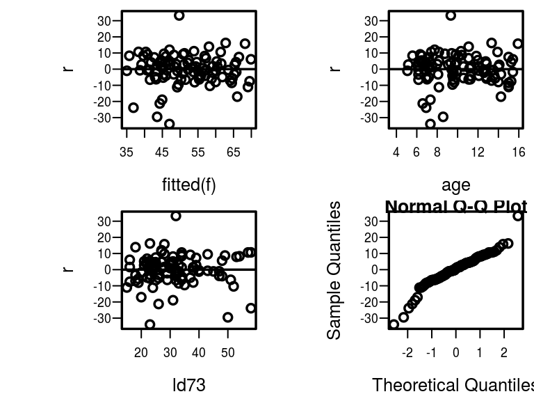

```r
r <- resid(f)
par(mfrow=c(2,2))   # 2x2 matrix of plots
plot(fitted(f), r); abline(h=0)  # yhat vs. r
with(lead, plot(age,  r));    abline(h=0)
with(lead, plot(ld73, r));    abline(h=0)
qqnorm(r)           # linearity indicates normality
```

# Partial Effects of Predictors

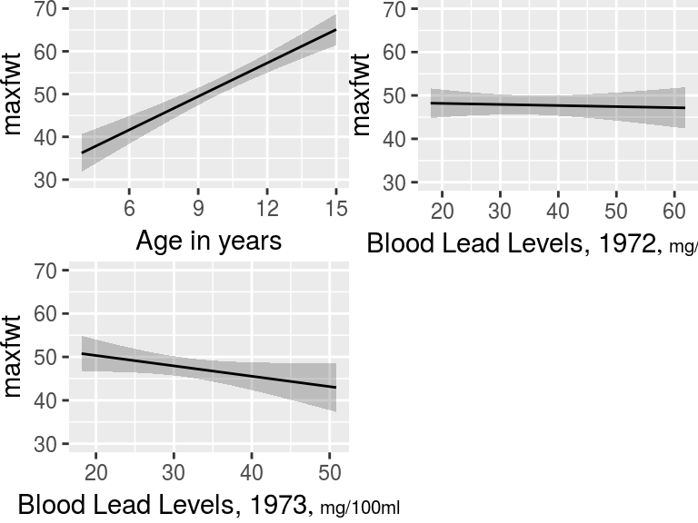

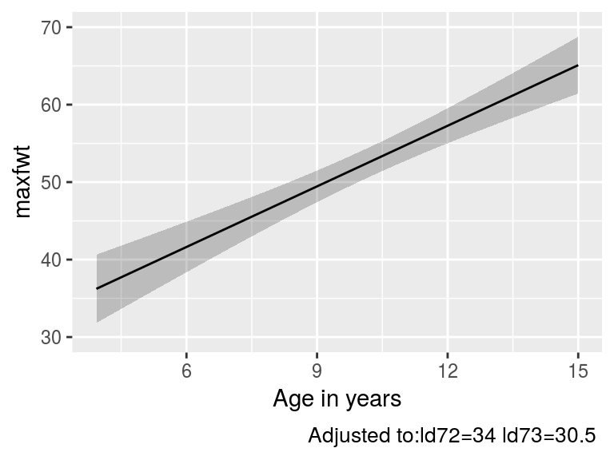

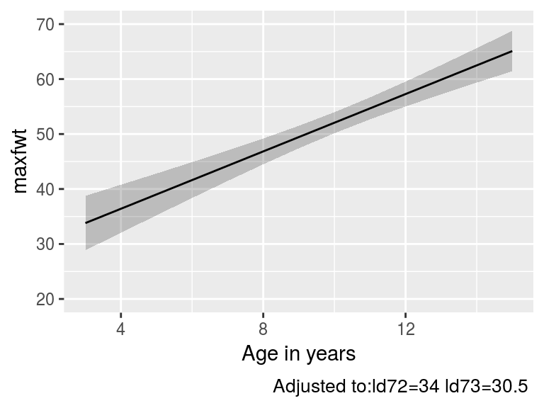

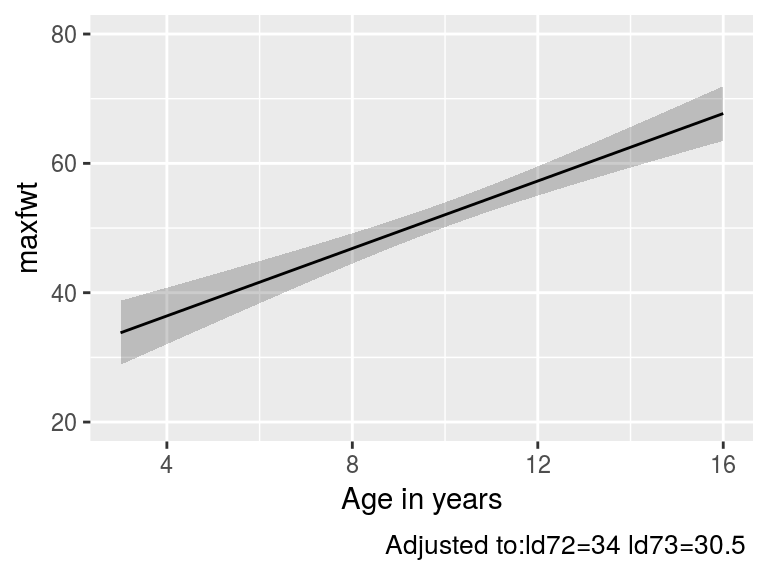

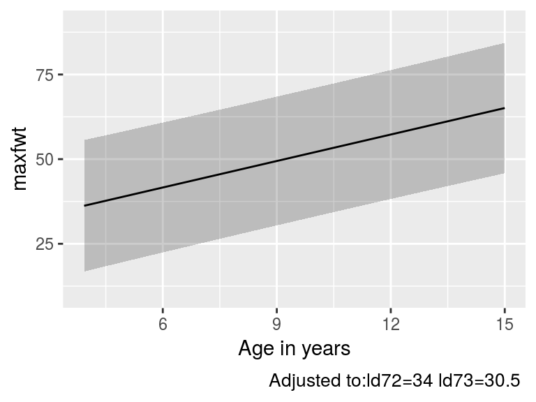

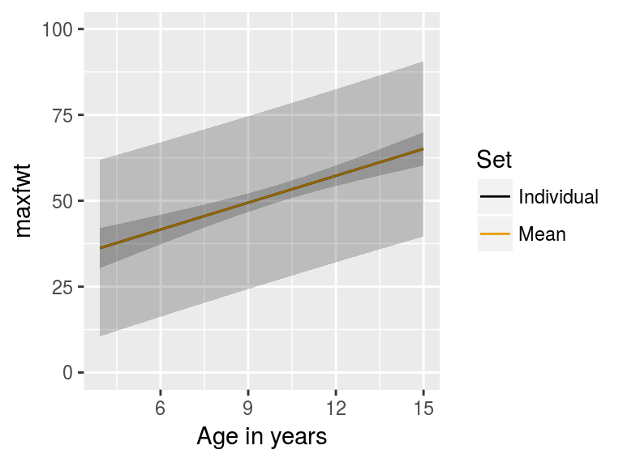

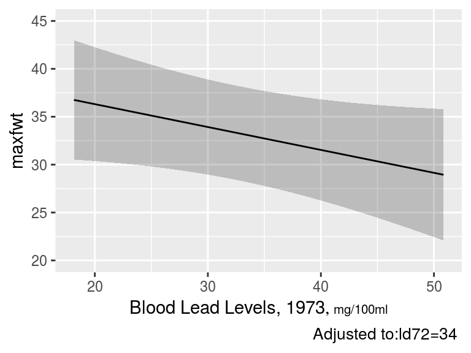

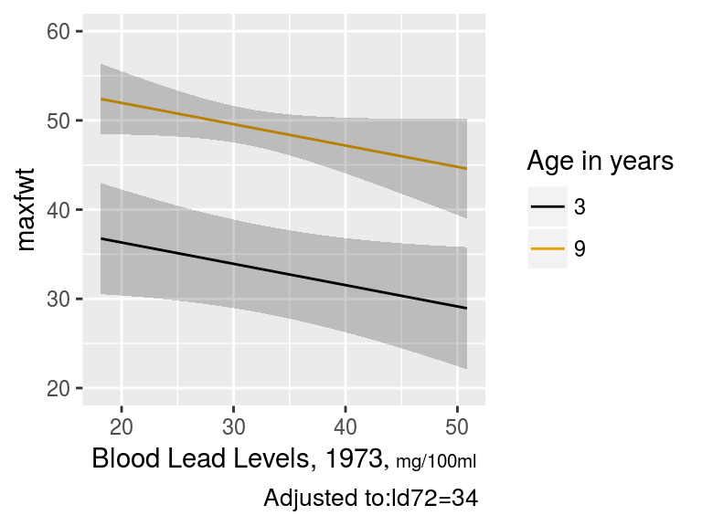

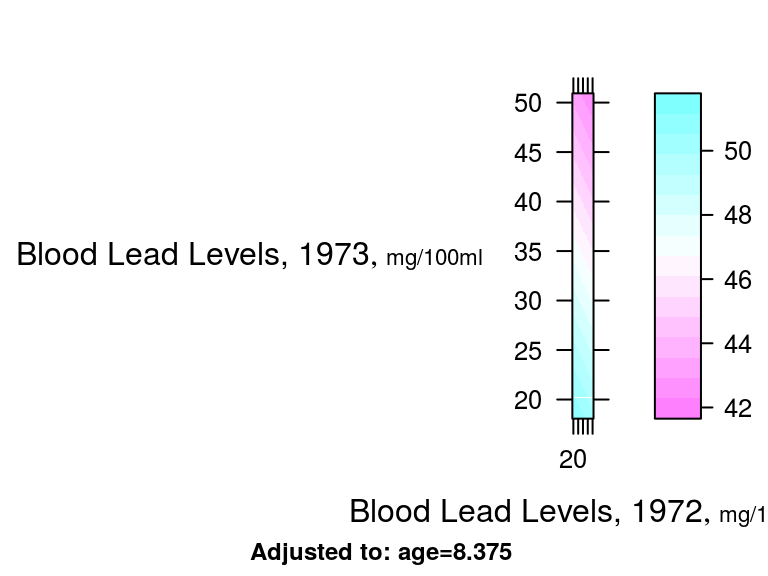

```r
ggplot(Predict(f))
ggplot(Predict(f, age))   # plot only age effect, using default range,
                          # 10th smallest to 10th largest age
ggplot(Predict(f, age=3:15))  # plot age=3,4,...,15
ggplot(Predict(f, age=seq(3,16,length=150)))   # plot age=3-16, 150 points
# Get confidence limits for individual response
ggplot(Predict(f, age, conf.type='individual'))
# Show both types of 0.99 confidence limits on one plot
p1 <- Predict(f, age, conf.int=0.99, conf.type='individual')
p2 <- Predict(f, age, conf.int=0.99, conf.type='mean')
p <- rbind(Individual=p1, Mean=p2)
ggplot(p)

# Non-plotted variables are set to reference values (median and
#  mode by default). To control the settings of non-plotted values use e.g.
ggplot(Predict(f, ld73, age=3))

# To make separate lines for two ages:
ggplot(Predict(f, ld73, age=c(3,9)))  # add ,conf.int=FALSE to suppress conf. bands
# To plot a 3-d surface for two continuous predictors against
#  yhat; color coding for predicted mean maxfwt
bplot(Predict(f, ld72, ld73))
```

# Point Estimates for Partial Effects

The `summary` function can compute point estimates and confidence intervals for effects of individual predictors, holding other predictors to selected constants. The constants you hold other predictors to will only matter when the other predictors interact with the predictor whose effects are being displayed.

How predictors are changed depend on the type of predictor: - Categorical predictors: differences against the reference (most frequent) cell by default - Continuous predictors: inter-quartile-range effects by default

The estimated effects depend on the type of model: - `ols`: differences in means - logistic models: odds ratios and their logs - Cox models: hazard ratios and their logs - quantile regression: differences in quantiles

```r
summary(f)         # inter-quartile-range effects
summary(f, age=5)  # adjust age to 5 when examining ld72,ld73
                   # (no effect since no interactions in model)
summary(f, ld73=c(20, 40))  # effect of changing ld73 from 20 to 40
```

[output not shown]

There is a `plot` method for `summary` results. By default it shows 0.9, 0.95, and 0.99 confidence limits.

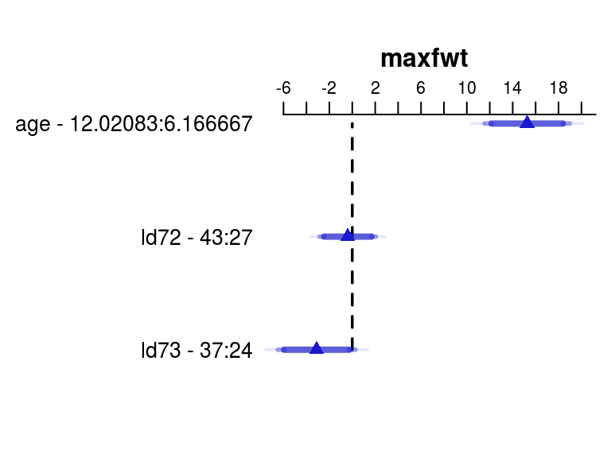

```r
# top=2 in chunk header: leave extra room for labels
plot(summary(f))
```

# Getting Predicted Values

## Using `predict`

```r
predict(f, data.frame(age=3, ld72=21, ld73=21))
```

```
       1
36.39448
```

```r
# must specify all variables in the model

predict(f, data.frame(age=c(3, 10), ld72=21, ld73=c(21, 47)))
```

```
       1        2
36.39448 48.43618
```

```r
# predictions for (3,21,21) and (10,21,47)

newdat <- expand.grid(age=c(4, 8), ld72=c(21, 47), ld73=c(21, 47))
newdat
```

```
  age ld72 ld73
1   4   21   21
2   8   21   21
3   4   47   21
4   8   47   21
5   4   21   47
6   8   21   47
7   4   47   47
8   8   47   47
```

```r
predict(f, newdat)     # 8 predictions
```

```
       1        2        3        4        5        6        7        8
39.00232 49.43370 38.36278 48.79416 32.78911 43.22049 32.14957 42.58095
```

```r
predict(f, newdat, conf.int=0.95)  # also get CLs for mean
```

```
$linear.predictors
       1        2        3        4        5        6        7        8
39.00232 49.43370 38.36278 48.79416 32.78911 43.22049 32.14957 42.58095

$lower
       1        2        3        4        5        6        7        8
33.97441 46.23595 32.15468 43.94736 25.68920 36.94167 27.17060 38.86475

$upper
       1        2        3        4        5        6        7        8
44.03023 52.63145 44.57088 53.64095 39.88902 49.49932 37.12854 46.29716
```

```r
predict(f, newdat, conf.int=0.95, conf.type='individual')  # CLs for indiv.
```

```
$linear.predictors
       1        2        3        4        5        6        7        8
39.00232 49.43370 38.36278 48.79416 32.78911 43.22049 32.14957 42.58095

$lower
       1        2        3        4        5        6        7        8
19.44127 30.26132 18.46566 29.27888 12.59596 23.30120 12.60105 23.31531

$upper
       1        2        3        4        5        6        7        8
58.56337 68.60609 58.25989 68.30944 52.98227 63.13979 51.69810 61.84659
```

## The brute-force way

```r
# Model is b1 + b2*age + b3*ld72 + b4*ld73
b <- coef(f)
# For 3 year old with both lead exposures 21
b[1] + b[2]*3 + b[3]*21 + b[4]*21
```

```
Intercept
 36.39448
```

## Using `Function` function

```r
g <- Function(f)
g(age=c(3, 8), ld72=21, ld73=21)       # 2 predictions
```

```
[1] 36.39448 49.43370
```

```r
g(age=3)              # 3 year old at median ld72, ld73
```

```
[1] 33.80449
```

# General ANOVA

- Use `anova(fitobject)` to get all total effects and individual partial effects
- Use `anova(f,age,sex)` to get combined partial effects of `age` and `sex`, for example
- Store result of `anova` in an object in you want to print it various ways, or to plot it:

```r
options(prType='plain')# so names,subscripts,dots work
an <- anova(f)
an                     # same as print(an)
```

```
                Analysis of Variance          Response: maxfwt

 Factor     d.f. Partial SS  MS          F     P
 age         1   5907.535742 5907.535742 65.15 <.0001
 ld72        1      8.972994    8.972994  0.10 0.7538
 ld73        1    295.044370  295.044370  3.25 0.0744
 REGRESSION  3   7540.087710 2513.362570 27.72 <.0001
 ERROR      95   8613.750674   90.671060
```

```r
print(an, 'names')     # print names of variables being tested
```

```
                Analysis of Variance          Response: maxfwt

 Factor     d.f. Partial SS  MS          F     P      Tested
 age         1   5907.535742 5907.535742 65.15 <.0001 age
 ld72        1      8.972994    8.972994  0.10 0.7538 ld72
 ld73        1    295.044370  295.044370  3.25 0.0744 ld73
 REGRESSION  3   7540.087710 2513.362570 27.72 <.0001 age,ld72,ld73
 ERROR      95   8613.750674   90.671060
```

```r
print(an, 'subscripts')# print subscripts in coef(f) (ignoring
```

```
                Analysis of Variance          Response: maxfwt

 Factor     d.f. Partial SS  MS          F     P      Tested
 age         1   5907.535742 5907.535742 65.15 <.0001 1
 ld72        1      8.972994    8.972994  0.10 0.7538 2
 ld73        1    295.044370  295.044370  3.25 0.0744 3
 REGRESSION  3   7540.087710 2513.362570 27.72 <.0001 1-3
 ERROR      95   8613.750674   90.671060

Subscripts correspond to:
[1] age  ld72 ld73
```

```r
                       # the intercept) being tested
print(an, 'dots')      # a dot in each position being tested
```

```
                Analysis of Variance          Response: maxfwt

 Factor     d.f. Partial SS  MS          F     P      Tested
 age         1   5907.535742 5907.535742 65.15 <.0001 .
 ld72        1      8.972994    8.972994  0.10 0.7538  .
 ld73        1    295.044370  295.044370  3.25 0.0744   .
 REGRESSION  3   7540.087710 2513.362570 27.72 <.0001 ...
 ERROR      95   8613.750674   90.671060

Subscripts correspond to:
[1] age  ld72 ld73
```

```r
anova(f, ld72, ld73)   # combine effects into a 2 d.f. test
```

```
                Analysis of Variance          Response: maxfwt

 Factor     d.f. Partial SS  MS         F    P
 ld72        1      8.972994   8.972994 0.10 0.7538
 ld73        1    295.044370 295.044370 3.25 0.0744
 REGRESSION  2    747.283558 373.641779 4.12 0.0192
 ERROR      95   8613.750674  90.671060
```

R Core Team (2017). *R: A Language and Environment for Statistical Computing*. R Foundation for Statistical Computing, Vienna, Austria. <URL: https://www.R-project.org/>.